# Credit Default Risk

```r
library(tidyverse)
library(skimr)
library(sqldf)
library(recipes)
train <- read_csv("application_train.csv")
test  <- read_csv("application_test.csv")
bureau <- read.csv('bureau.csv')
bureau_balance <- read.csv('bureau_balance.csv')
credit_card_balance <- read.csv('credit_card_balance.csv')
columns_description <- read.csv('HomeCredit_columns_description.csv')
installments_payments <- read.csv('installments_payments.csv')
pos_cash <- read.csv('POS_CASH_balance.csv')
previous_app <- read.csv('previous_application.csv')
sample_submit <- read.csv('sample_submission.csv')
```

```r
skim_to_list(train)
```

```
## $character
## # A tibble: 16 x 8
##    variable               missing complete n     min   max   empty n_unique
##  * <chr>                  <chr>   <chr>    <chr> <chr> <chr> <chr> <chr>
##  1 CODE_GENDER            0       307511   3075~ 1     3     0     3
##  2 EMERGENCYSTATE_MODE    145755  161756   3075~ 2     3     0     2
##  3 FLAG_OWN_CAR           0       307511   3075~ 1     1     0     2
##  4 FLAG_OWN_REALTY        0       307511   3075~ 1     1     0     2
##  5 FONDKAPREMONT_MODE     210295  97216    3075~ 13    21    0     4
##  6 HOUSETYPE_MODE         154297  153214   3075~ 14    16    0     3
##  7 NAME_CONTRACT_TYPE     0       307511   3075~ 10    15    0     2
##  8 NAME_EDUCATION_TYPE    0       307511   3075~ 15    29    0     5
##  9 NAME_FAMILY_STATUS     0       307511   3075~ 5     20    0     6
## 10 NAME_HOUSING_TYPE      0       307511   3075~ 12    19    0     6
## 11 NAME_INCOME_TYPE       0       307511   3075~ 7     20    0     8
```

[output cut: 21 more lines]

Let’s examine the percentage of missing values in the data. We will remove columns that have more than 50% NA values. These columns are not as useful and when we impute, we prefer to do minimal imputation.

```r
options(scipen = 999)

train <- train[,apply(train, 2, function(x){(sum(is.na(x)) / nrow(train)) < 0.5}) != FALSE]

temp <- train

lapply(temp, function(x) mean(is.na(x)))
```

```
## $SK_ID_CURR
## [1] 0
##
## $TARGET
## [1] 0
##
## $NAME_CONTRACT_TYPE
## [1] 0
##
## $CODE_GENDER
## [1] 0
##
## $FLAG_OWN_CAR
## [1] 0
##
## $FLAG_OWN_REALTY
## [1] 0
##
## $CNT_CHILDREN
## [1] 0
##
## $AMT_INCOME_TOTAL
## [1] 0
##
## $AMT_CREDIT
## [1] 0
##
## $AMT_ANNUITY
## [1] 0.00003902299
##
## $AMT_GOODS_PRICE
## [1] 0.0009040327
##
## $NAME_TYPE_SUITE
## [1] 0.004201476
##
## $NAME_INCOME_TYPE
## [1] 0
##
## $NAME_EDUCATION_TYPE
```

[output cut: 187 more lines]

```
##
## $AMT_REQ_CREDIT_BUREAU_DAY
## [1] 0.1350163
##
## $AMT_REQ_CREDIT_BUREAU_WEEK
## [1] 0.1350163
##
## $AMT_REQ_CREDIT_BUREAU_MON
## [1] 0.1350163
##
## $AMT_REQ_CREDIT_BUREAU_QRT
## [1] 0.1350163
##
## $AMT_REQ_CREDIT_BUREAU_YEAR
## [1] 0.1350163
```

Now, we will prepare to make character columns into factor columns. We will also make numeric columns that have a low number of unique values into factor columns (or categorical) columns.

```r
string_2_factor_names <- temp %>%
    select_if(is.character) %>%
    names()

string_2_factor_names
```

```
##  [1] "NAME_CONTRACT_TYPE"         "CODE_GENDER"
##  [3] "FLAG_OWN_CAR"               "FLAG_OWN_REALTY"
##  [5] "NAME_TYPE_SUITE"            "NAME_INCOME_TYPE"
##  [7] "NAME_EDUCATION_TYPE"        "NAME_FAMILY_STATUS"
##  [9] "NAME_HOUSING_TYPE"          "OCCUPATION_TYPE"
## [11] "WEEKDAY_APPR_PROCESS_START" "ORGANIZATION_TYPE"
## [13] "EMERGENCYSTATE_MODE"
```

```r
unique_numeric_values_tbl <- temp %>%
    select_if(is.numeric) %>%
    map_df(~ unique(.) %>% length()) %>%
    gather() %>%
    arrange(value) %>%
    mutate(key = as_factor(key))

unique_numeric_values_tbl
```

```
## # A tibble: 68 x 2
##    key                         value
##    <fct>                       <int>
##  1 TARGET                          2
##  2 FLAG_MOBIL                      2
##  3 FLAG_EMP_PHONE                  2
##  4 FLAG_WORK_PHONE                 2
##  5 FLAG_CONT_MOBILE                2
##  6 FLAG_PHONE                      2
##  7 FLAG_EMAIL                      2
##  8 REG_REGION_NOT_LIVE_REGION      2
##  9 REG_REGION_NOT_WORK_REGION      2
## 10 LIVE_REGION_NOT_WORK_REGION     2
## # ... with 58 more rows
```

We will use 7 as a threshold. Columns that have less than 7 unique values will be turned into categorical columns.

```r
factor_limit <- 7

num_2_factor_names <- unique_numeric_values_tbl %>%
    filter(value < factor_limit) %>%
    arrange(desc(value)) %>%
    pull(key) %>%
    as.character()

num_2_factor_names
```

```
##  [1] "AMT_REQ_CREDIT_BUREAU_HOUR"  "REGION_RATING_CLIENT"
##  [3] "REGION_RATING_CLIENT_W_CITY" "TARGET"
##  [5] "FLAG_MOBIL"                  "FLAG_EMP_PHONE"
##  [7] "FLAG_WORK_PHONE"             "FLAG_CONT_MOBILE"
##  [9] "FLAG_PHONE"                  "FLAG_EMAIL"
## [11] "REG_REGION_NOT_LIVE_REGION"  "REG_REGION_NOT_WORK_REGION"
## [13] "LIVE_REGION_NOT_WORK_REGION" "REG_CITY_NOT_LIVE_CITY"
## [15] "REG_CITY_NOT_WORK_CITY"      "LIVE_CITY_NOT_WORK_CITY"
## [17] "FLAG_DOCUMENT_2"             "FLAG_DOCUMENT_3"
## [19] "FLAG_DOCUMENT_4"             "FLAG_DOCUMENT_5"
## [21] "FLAG_DOCUMENT_6"             "FLAG_DOCUMENT_7"
## [23] "FLAG_DOCUMENT_8"             "FLAG_DOCUMENT_9"
## [25] "FLAG_DOCUMENT_10"            "FLAG_DOCUMENT_11"
## [27] "FLAG_DOCUMENT_12"            "FLAG_DOCUMENT_13"
## [29] "FLAG_DOCUMENT_14"            "FLAG_DOCUMENT_15"
## [31] "FLAG_DOCUMENT_16"            "FLAG_DOCUMENT_17"
## [33] "FLAG_DOCUMENT_18"            "FLAG_DOCUMENT_19"
## [35] "FLAG_DOCUMENT_20"            "FLAG_DOCUMENT_21"
```

```r
rec_obj <- recipe(~ ., data = temp) %>%
    step_string2factor(string_2_factor_names) %>%
    step_num2factor(num_2_factor_names) %>%
    prep(stringsAsFactors = FALSE)

rec_obj
```

```
## Data Recipe
##
## Inputs:
##
##       role #variables
##  predictor         81
##
## Training data contained 307511 data points and 222936 incomplete rows.
##
## Operations:
##
## Factor variables from NAME_CONTRACT_TYPE, ... [trained]
## Factor variables from 36 items [trained]
```

```r
temp_processed <- bake(rec_obj, temp)

head(temp_processed)
```

```
## # A tibble: 6 x 81
##   SK_ID_CURR TARGET NAME_CONTRACT_T~ CODE_GENDER FLAG_OWN_CAR
##        <dbl> <fct>  <fct>            <fct>       <fct>
## 1     100002 1      Cash loans       M           N
## 2     100003 0      Cash loans       F           N
## 3     100004 0      Revolving loans  M           Y
## 4     100006 0      Cash loans       F           N
## 5     100007 0      Cash loans       M           N
## 6     100008 0      Cash loans       M           N
## # ... with 76 more variables: FLAG_OWN_REALTY <fct>, CNT_CHILDREN <dbl>,
## #   AMT_INCOME_TOTAL <dbl>, AMT_CREDIT <dbl>, AMT_ANNUITY <dbl>,
## #   AMT_GOODS_PRICE <dbl>, NAME_TYPE_SUITE <fct>, NAME_INCOME_TYPE <fct>,
## #   NAME_EDUCATION_TYPE <fct>, NAME_FAMILY_STATUS <fct>,
## #   NAME_HOUSING_TYPE <fct>, REGION_POPULATION_RELATIVE <dbl>,
## #   DAYS_BIRTH <dbl>, DAYS_EMPLOYED <dbl>, DAYS_REGISTRATION <dbl>,
## #   DAYS_ID_PUBLISH <dbl>, FLAG_MOBIL <fct>, FLAG_EMP_PHONE <fct>,
## #   FLAG_WORK_PHONE <fct>, FLAG_CONT_MOBILE <fct>, FLAG_PHONE <fct>,
## #   FLAG_EMAIL <fct>, OCCUPATION_TYPE <fct>, CNT_FAM_MEMBERS <dbl>,
## #   REGION_RATING_CLIENT <fct>, REGION_RATING_CLIENT_W_CITY <fct>,
## #   WEEKDAY_APPR_PROCESS_START <fct>, HOUR_APPR_PROCESS_START <dbl>,
## #   REG_REGION_NOT_LIVE_REGION <fct>, REG_REGION_NOT_WORK_REGION <fct>,
## #   LIVE_REGION_NOT_WORK_REGION <fct>, REG_CITY_NOT_LIVE_CITY <fct>,
## #   REG_CITY_NOT_WORK_CITY <fct>, LIVE_CITY_NOT_WORK_CITY <fct>,
## #   ORGANIZATION_TYPE <fct>, EXT_SOURCE_2 <dbl>, EXT_SOURCE_3 <dbl>,
## #   YEARS_BEGINEXPLUATATION_AVG <dbl>, FLOORSMAX_AVG <dbl>,
## #   YEARS_BEGINEXPLUATATION_MODE <dbl>, FLOORSMAX_MODE <dbl>,
## #   YEARS_BEGINEXPLUATATION_MEDI <dbl>, FLOORSMAX_MEDI <dbl>,
## #   TOTALAREA_MODE <dbl>, EMERGENCYSTATE_MODE <fct>,
## #   OBS_30_CNT_SOCIAL_CIRCLE <dbl>, DEF_30_CNT_SOCIAL_CIRCLE <dbl>,
## #   OBS_60_CNT_SOCIAL_CIRCLE <dbl>, DEF_60_CNT_SOCIAL_CIRCLE <dbl>,
## #   DAYS_LAST_PHONE_CHANGE <dbl>, FLAG_DOCUMENT_2 <fct>,
## #   FLAG_DOCUMENT_3 <fct>, FLAG_DOCUMENT_4 <fct>, FLAG_DOCUMENT_5 <fct>,
## #   FLAG_DOCUMENT_6 <fct>, FLAG_DOCUMENT_7 <fct>, FLAG_DOCUMENT_8 <fct>,
## #   FLAG_DOCUMENT_9 <fct>, FLAG_DOCUMENT_10 <fct>, FLAG_DOCUMENT_11 <fct>,
## #   FLAG_DOCUMENT_12 <fct>, FLAG_DOCUMENT_13 <fct>,
## #   FLAG_DOCUMENT_14 <fct>, FLAG_DOCUMENT_15 <fct>,
## #   FLAG_DOCUMENT_16 <fct>, FLAG_DOCUMENT_17 <fct>,
## #   FLAG_DOCUMENT_18 <fct>, FLAG_DOCUMENT_19 <fct>,
## #   FLAG_DOCUMENT_20 <fct>, FLAG_DOCUMENT_21 <fct>,
## #   AMT_REQ_CREDIT_BUREAU_HOUR <fct>, AMT_REQ_CREDIT_BUREAU_DAY <dbl>,
## #   AMT_REQ_CREDIT_BUREAU_WEEK <dbl>, AMT_REQ_CREDIT_BUREAU_MON <dbl>,
## #   AMT_REQ_CREDIT_BUREAU_QRT <dbl>, AMT_REQ_CREDIT_BUREAU_YEAR <dbl>
```

Checking to see if data processing worked correctly

```r
class(temp$FLAG_PHONE) #this was originally numeric
```

```
## [1] "numeric"
```

```r
class(temp_processed$FLAG_PHONE) #now it is a factor
```

```
## [1] "factor"
```

```r
class(temp$REG_CITY_NOT_LIVE_CITY) #this was originally numeric
```

```
## [1] "numeric"
```

```r
class(temp_processed$REG_CITY_NOT_LIVE_CITY) #now it is a factor
```

```
## [1] "factor"
```

```r
class(temp$TARGET) #this was originally numeric
```

```
## [1] "numeric"
```

```r
class(temp_processed$TARGET) #now it is a factor
```

```
## [1] "factor"
```

Let’s recap. We have temp_processed which includes columns with less than 50% NA’s only. We also converted character columns into factor columns. We also concerted certain numeric columns into factor (categorical) columns due to low number of unique values.

# Exploratory Data Analysis

Now, we will conduct EDA with SQL and other tools.

We will take a look at certain columns of interest.

## AMT_CREDIT (loan amount)

```r
summary(temp_processed$AMT_CREDIT)
```

```
##    Min. 1st Qu.  Median    Mean 3rd Qu.    Max.
##   45000  270000  513531  599026  808650 4050000
```

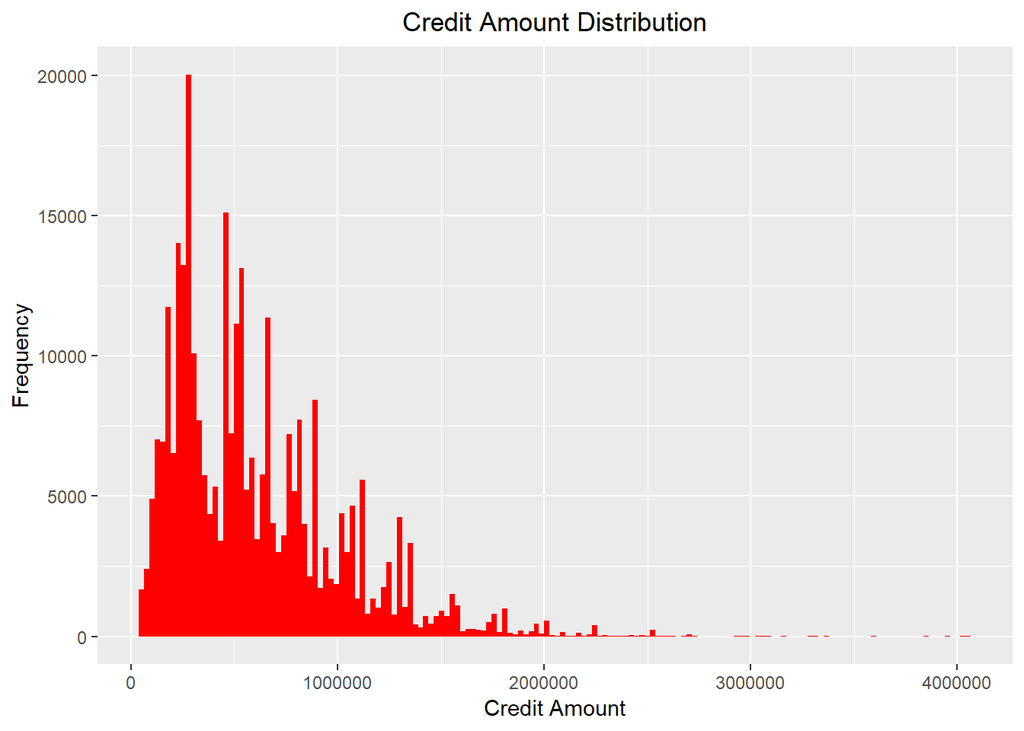

```r
ggplot(data = temp_processed, aes(x = AMT_CREDIT)) +
  geom_histogram(aes(y = ..count..), binwidth = 1.75 * IQR(temp_processed$AMT_CREDIT) / nrow(temp_processed)^(1/3.5) , fill = 'red')+
  labs(title='Credit Amount Distribution')+
  labs(x='Credit Amount',y = 'Frequency') +
  theme(plot.title = element_text(hjust = 0.5))
```

The mean is roughly 600,000.

## Relationship between Gender and Default Rate

```r
male <- subset(temp_processed, CODE_GENDER == 'M')
female <- subset(temp_processed, CODE_GENDER == 'F')

male_prop <- mean(male$TARGET == '1') #0.10
female_prop <- mean(female$TARGET == '1') #0.70

male_default <- sum(male$TARGET == '1')
female_default <- sum(female$TARGET == '1')


res <- prop.test(x = c(male_default, female_default), n = c(nrow(male), nrow(female)))
res
```

```
##
##  2-sample test for equality of proportions with continuity
##  correction
##
## data:  c(male_default, female_default) out of c(nrow(male), nrow(female))
## X-squared = 920.01, df = 1, p-value < 0.00000000000000022
## alternative hypothesis: two.sided
## 95 percent confidence interval:
##  0.02928154 0.03357031
## sample estimates:
##     prop 1     prop 2
## 0.10141920 0.06999328
```

Our result is significant, but since our data is so huge it’s probably a good idea to take a look at effect size.

Effect size is represented as h.

$$h = \phi_{1} - \phi_{2}$$

Where:

$$\phi_{i} = 2sin^{-1}(\sqrt{p_{i}})$$

```r
effect_size_2prop <- function(prop1, prop2){

  return((2 * asin(sqrt(prop1))) - (2 * asin(sqrt(prop2))))

}

effect_size_2prop(male_prop, female_prop)
```

```
## [1] 0.1127167
```

According to our effect size, there does not seem to be a significant difference. However, let’s keep gender in mind when we start constructing our predictive model since the difference in default risk is a little over 0.03.

## Owning a Car or Home and Default Rate

We can assume that those who do not own a car or a home/flat are renting one. It could be true that those who are paying monthly bills for their home and car might have a harder time paying back other loans. Let’s see if this is the case.

```r
renting_home_car <- sqldf("SELECT FLAG_OWN_REALTY, FLAG_OWN_CAR, AVG(TARGET) AS default_rate
                           FROM temp_processed
                           GROUP BY FLAG_OWN_REALTY, FLAG_OWN_CAR
                           ORDER BY AVG(TARGET)")

renting_home_car
```

```
##   FLAG_OWN_REALTY FLAG_OWN_CAR default_rate
## 1               N            Y   0.07043783
## 2               Y            Y   0.07332781
## 3               Y            N   0.08284380
## 4               N            N   0.08991157
```

We found that our claim has some truth to it. Those who are renting both a home and leasing a car have a slightly higher default rate. However if we think about it, this difference in default rate is actually quite big.

Default rates typically would not be that high across different categories. In most situations, the default rate would hover around 10%. Therefore, a small difference of 1 or 2% can be considered significant.

In our case, the difference in default rate between YY and NN is 1.66%

## Income and Default Rate

```r
quantile(temp_processed$AMT_INCOME_TOTAL, probs = c(0, 0.25, 0.50, 0.75,1))
```

```
##        0%       25%       50%       75%      100%
##     25650    112500    147150    202500 117000000
```

```r
income_default <- sqldf("SELECT CASE WHEN AMT_INCOME_TOTAL <= 147150 THEN 'LOW'
                                     WHEN AMT_INCOME_TOTAL > 147150 THEN 'HIGH'

                                END AS 'Income_Level',

                         AVG(TARGET) AS default_rate
                         FROM temp_processed
                         GROUP BY Income_Level
                         ORDER BY default_rate DESC")

income_default
```

```
##   Income_Level default_rate
## 1          LOW   0.08441727
## 2         HIGH   0.07704015
```

It seems that income level with 2 classes could explain/predict default rate fairly well. We see that the difference in default rate between low and high income is 0.74% which could be significant.

## Number of Children and Default Rate

```r
table(temp_processed$CNT_CHILDREN)
```

```
##
##      0      1      2      3      4      5      6      7      8      9
## 215371  61119  26749   3717    429     84     21      7      2      2
##     10     11     12     14     19
##      2      1      2      3      2
```

```r
childrencount_default <- sqldf("SELECT CASE WHEN CNT_CHILDREN = 0 THEN 'NO CHILDREN'
                                            WHEN CNT_CHILDREN IN (1,2) THEN 'HAS CHILDREN'
                                            ELSE 'MANY CHILDREN' END AS 'Number_of_Children',
                                AVG(TARGET) AS default_rate
                                FROM temp_processed
                                GROUP BY Number_of_Children
                                ORDER BY default_rate")


childrencount_default
```

```
##   Number_of_Children default_rate
## 1        NO CHILDREN   0.07711809
## 2       HAS CHILDREN   0.08862157
## 3      MANY CHILDREN   0.10042135
```

The decision to group CNT_CHILDREN into the 3 categories is based on the fact that there are not many clients who have a high number of children such as 10, 14, or 19.

In fact, there are only 3 clients who have 14 children and only 2 who have 19 children. Since the expected default rate is already very low and we have low counts, we got 0% for default. This would make it seem as if people with many children have a low default rate which likely is not the case.

Therefore, I have grouped 1 or 2 children as “HAS CHILDREN”, more than 2 children as “MANY CHILDREN” and 0 as “NO CHILDREN”.

From the SQL query we notice that there is a huge difference in default rate (2.3%) between “NO CHILDREN” and “MANY CHILDREN”.

Clients that have to spend a huge amount of money on many children would be more likely to default because they have extra expenses they need to worry about.

## Type of Loan and Default Rate

There are 2 types of loans in our data. One of them is a cash loan and the other one is a revolving loan.

Revolving loans are loans in which the client can withdraw, repay, and withdraw again usually an unlimited number of times (unless they go over their limit). When we think of revolving loans, we usually think of credit cards since they behave this way.

A cash loan is like a “one-time” loan such as a loan to buy a house, car, or something else.

```r
table(temp_processed$NAME_CONTRACT_TYPE)
```

```
##
##      Cash loans Revolving loans
##          278232           29279
```

```r
mean(temp_processed$NAME_CONTRACT_TYPE == 'Cash loans')
```

```
## [1] 0.9047871
```

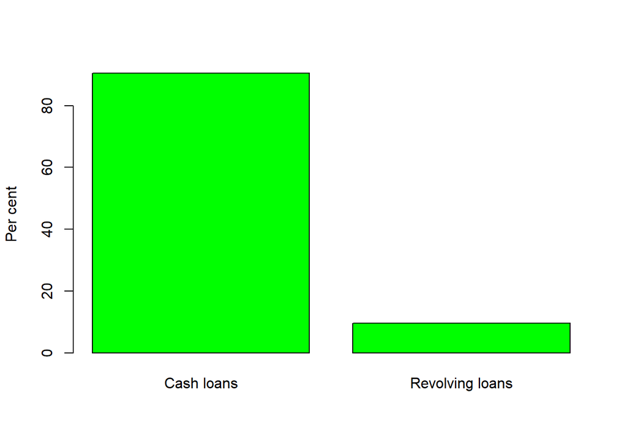

```r
t <- table(temp_processed$NAME_CONTRACT_TYPE); barplot(t/sum(t)*100,ylab="Per cent", col = 'green')
```

We see that 90.5% of loans from Home Credit are cash loans.

Would the default rate be significantly differ depending on which loan the client takes out? Let’s find out.

```r
sqldf("SELECT NAME_CONTRACT_TYPE, AVG(TARGET) AS default_rate
       FROM temp_processed
       GROUP BY NAME_CONTRACT_TYPE
       ORDER BY default_rate ")
```

```
##   NAME_CONTRACT_TYPE default_rate
## 1    Revolving loans   0.05478329
## 2         Cash loans   0.08345913
```

```r
sqldf("SELECT NAME_CONTRACT_TYPE, AVG(AMT_CREDIT) AS loan_amount
       FROM temp_processed
       GROUP BY NAME_CONTRACT_TYPE
       ORDER BY loan_amount")
```

```
##   NAME_CONTRACT_TYPE loan_amount
## 1    Revolving loans    324018.0
## 2         Cash loans    627965.7
```

## Age of Client

The age of client is represented in days at the time of the application.

To make the this column more interpretable and understandable for us, it’s probably a better idea to divide by 365.

```r
temp_processed$DAYS_BIRTH <- (-1) * (temp_processed$DAYS_BIRTH / 365)

summary(temp_processed$DAYS_BIRTH)
```

```
##    Min. 1st Qu.  Median    Mean 3rd Qu.    Max.
##   20.52   34.01   43.15   43.94   53.92   69.12
```

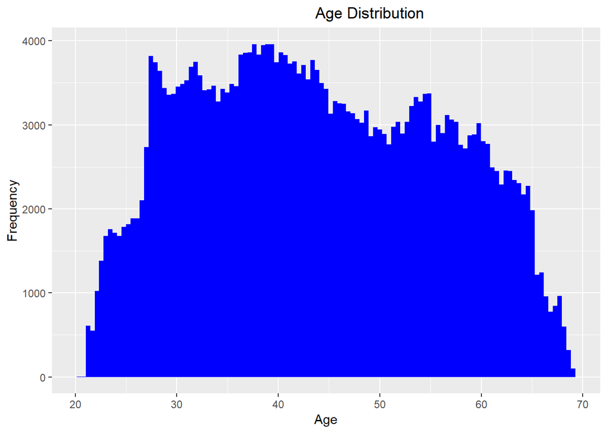

```r
ggplot(data = temp_processed, aes(x = DAYS_BIRTH)) +
  geom_histogram(aes(y = ..count..), binwidth = 1.5 * IQR(temp_processed$DAYS_BIRTH) / nrow(temp_processed)^(1/3) , fill = 'blue')+
  labs(title='Age Distribution')+
  labs(x='Age',y = 'Frequency') +
  theme(plot.title = element_text(hjust = 0.6))
```

We see that the distribution of age seems rather uniform, expect that it dips down at the sides. This makes sense since people in their early 20’s would likely still be in college and so they would not need to take out too many loans. People in their late 60’s are likely retired and like students, would probably not be taking out loans at that point in their life.

## Examination of Other Categorical Features

### Occupation Type Distribution

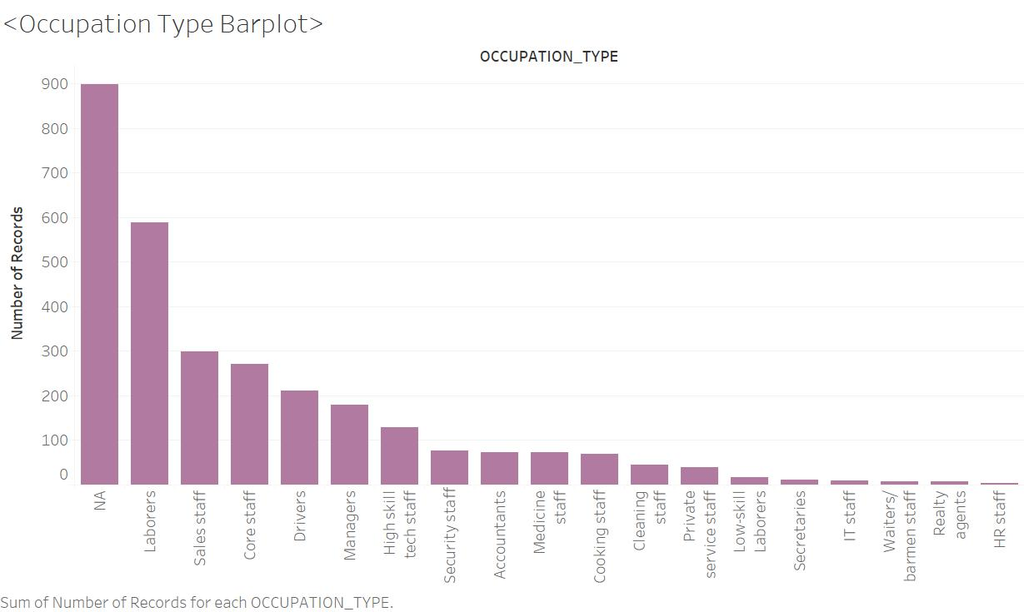

```r
knitr::include_graphics('occupation_dist.jpg')
```

I decided to use Tableau for making this visualization. This visualization was based on a random sample of the data. Tableau won’t be able to handle such large data, and I figured a sample size of 3000 would be representative of the population distribution.

We see that an overwhelming majority of clients come from the following categories:

Laborers, Sales Staff, Core Staff, Drivers, Managers, High Skill Tech Staff

### Previous Application: Status of Previous Application

```r
prev_app_status <- as.data.frame(table(previous_app$NAME_CONTRACT_STATUS))

colnames(prev_app_status) <- c('Status', 'Frequecy')

prev_app_status
```

```
##         Status Frequecy
## 1     Approved  1036781
## 2     Canceled   316319
## 3      Refused   290678
## 4 Unused offer    26436
```

```r
dat = data.frame(count = c(1036781, 316319,290678,26436), category = c('Approved', 'Canceled', 'Refused', 'Unused Offer'))

dat$fraction = dat$count / sum(dat$count)
dat = dat[order(dat$fraction), ]
dat$ymax = cumsum(dat$fraction)
dat$ymin = c(0, head(dat$ymax, n=-1))

dat
```

```
##     count     category   fraction       ymax       ymin
## 4   26436 Unused Offer 0.01582791 0.01582791 0.00000000
## 3  290678      Refused 0.17403638 0.18986429 0.01582791
## 2  316319     Canceled 0.18938831 0.37925260 0.18986429
## 1 1036781     Approved 0.62074740 1.00000000 0.37925260
```

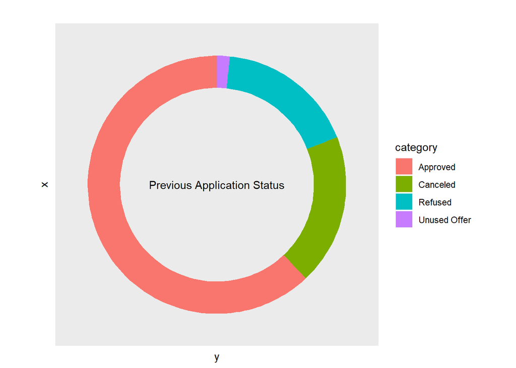

```r
# Make the plot
p1 = ggplot(dat, aes(fill=category, ymax=ymax, ymin=ymin, xmax=4, xmin=3)) +
     geom_rect() +
     coord_polar(theta="y") +
     xlim(c(0, 4)) +
     theme(panel.grid=element_blank()) +
     theme(axis.text=element_blank()) +
     theme(axis.ticks=element_blank()) +
     annotate("text", x = 0, y = 0, label = "Previous Application Status") +
     labs(title="")
p1
```

Here we notice that approximately 17.4% of previous applications were rejected. This could be an important feature in our model. We can use information about whether or not a previous application was rejected or not (0 or 1, binary) to determine the likelihood of the current loan being defaulted. ‘Canceled’ could also give some insight. If somebody cancels their loan application, the likelihood of that person being financially instable might be higher because they realized they cannot afford to pay back the loan.

# Feature Engineering

## Adding ‘Expected Age of Full Repayment’ feature (feature combines Age, AMT_ANNUITY, AMT_CREDIT)

```r
summary(temp_processed$AMT_CREDIT / temp_processed$AMT_ANNUITY)
```

```
##    Min. 1st Qu.  Median    Mean 3rd Qu.    Max.    NA's
##   8.037  15.614  20.000  21.612  27.100  45.305      12
```

```r
#for instance, if result is 0.05 then we are paying 5% of the loan back.
#assuming annuity payed every 30 days (or 1 month)

#then, 20 months to pay back loan in full

temp_processed$DAYS_BIRTH <- (-1) * temp_processed$DAYS_BIRTH * 365
```

```r
duration_to_pay <- temp_processed$AMT_CREDIT / temp_processed$AMT_ANNUITY

temp_processed$age_repay_estimate <- ((-1) * temp_processed$DAYS_BIRTH) + (duration_to_pay * 30)
```

## Updating CNT_CHILDREN Feature

```r
temp_processed <- sqldf("SELECT temp_processed.*,

                                            CASE WHEN CNT_CHILDREN = 0 THEN 'NO CHILDREN'
                                            WHEN CNT_CHILDREN IN (1,2) THEN 'HAS CHILDREN'
                                            ELSE 'MANY CHILDREN' END AS 'Number_of_Children'

                         FROM temp_processed



                        ")

temp_processed$CNT_CHILDREN <- NULL
```

## Updating CNT_FAM_MEMBERS

```r
familycount_default <- sqldf("SELECT CASE WHEN CNT_FAM_MEMBERS > 4 THEN 'HAS MANY FAMILY MEMBERS'
                                     ELSE 'HAS FAMILY MEMBERS' END AS 'Number_of_Family_Members',
                                AVG(TARGET) AS default_rate
                                FROM temp_processed
                                GROUP BY Number_of_Family_Members
                                ORDER BY default_rate")



familycount_default
```

```
##   Number_of_Family_Members default_rate
## 1       HAS FAMILY MEMBERS   0.08048658
## 2  HAS MANY FAMILY MEMBERS   0.09907662
```

```r
temp_processed <- sqldf("SELECT temp_processed.*,

                                     CASE WHEN CNT_FAM_MEMBERS > 4 THEN 'HAS MANY FAMILY MEMBERS'
                                     ELSE 'HAS FAMILY MEMBERS' END AS 'Number_of_Family_Members'

                         FROM temp_processed



                        ")



temp_processed$CNT_FAM_MEMBERS <- NULL
```

```r
library(caTools)
library(randomForest)
set.seed(7720489)

temp_processed$NAME_TYPE_SUITE <- as.factor(temp_processed$NAME_TYPE_SUITE)
temp_processed$OCCUPATION_TYPE <- as.factor(temp_processed$OCCUPATION_TYPE)
temp_processed$EMERGENCYSTATE_MODE <- as.factor(temp_processed$EMERGENCYSTATE_MODE)
temp_processed$AMT_REQ_CREDIT_BUREAU_HOUR <- as.factor(temp_processed$AMT_REQ_CREDIT_BUREAU_HOUR)
temp_processed$Number_of_Children <- as.factor(temp_processed$Number_of_Children)
temp_processed$Number_of_Family_Members <- as.factor(temp_processed$Number_of_Family_Members)
```

# Updating Categorical Columns

We must change categorical columns with many levels into numeric. Earlier we cleaned numeric data with only several unique values by turning them into categoricals, but not the other way around. We need to do this in order for random forest to run successfully.

```r
unique_categorical_levels_tbl <- temp_processed %>%
    select_if(is.factor) %>%
    map_df(~ unique(.) %>% length()) %>%
    gather() %>%
    arrange(value) %>%
    mutate(key = as_factor(key))

unique_categorical_levels_tbl
```

```
## # A tibble: 51 x 2
##    key                value
##    <fct>              <int>
##  1 TARGET                 2
##  2 NAME_CONTRACT_TYPE     2
##  3 FLAG_OWN_CAR           2
##  4 FLAG_OWN_REALTY        2
##  5 FLAG_MOBIL             2
##  6 FLAG_EMP_PHONE         2
##  7 FLAG_WORK_PHONE        2
##  8 FLAG_CONT_MOBILE       2
##  9 FLAG_PHONE             2
## 10 FLAG_EMAIL             2
## # ... with 41 more rows
```

The column that prevents us from running random forest successfully is ORGANIZATION_TYPE.

There are several approaches we can take to solve this issue. One option is to just not use that column when running random forest, and the other option is to collapse the number of levels manually by doing some grouping.

```r
organization <- sqldf("SELECT ORGANIZATION_TYPE, COUNT(*) AS count, AVG(TARGET) AS default_rate
       FROM temp_processed
       GROUP BY ORGANIZATION_TYPE
       ORDER BY default_rate DESC")

organization
```

```
##         ORGANIZATION_TYPE count default_rate
## 1       Transport: type 3  1187   0.15754002
## 2       Industry: type 13    67   0.13432836
## 3        Industry: type 8    24   0.12500000
## 4              Restaurant  1811   0.11706240
## 5            Construction  6721   0.11679810
## 6                Cleaning   260   0.11153846
## 7        Industry: type 1  1039   0.11068335
## 8        Industry: type 3  3278   0.10616229
## 9                 Realtor   396   0.10606061
## 10            Agriculture  2454   0.10472698
## 11          Trade: type 3  3492   0.10337915
## 12          Self-employed 38412   0.10173904
## 13       Industry: type 4   877   0.10148233
## 14               Security  3247   0.09978442
```

[output cut: 44 more lines]

It seems that ORGANIZATION_TYPE has some potential in being a useful predictor for defaulting. We notice that some levels such as “resturaunt” have a very high default rate whereas “police” has a low default rate.

Something interesting that we notice is that “military”, “police”, “university”, and “security ministries” have very low default rates. This could be because they are public sector jobs and these clients might be more loyal and obedient, and so are more likely to pay their loans on time.

Let’s try to group our levels a bit. Let’s group all the “type X” levels into their respective level. For instance, Industry: type 13 and Industry: type 8 will be grouped into just “Industry” and so on.

```r
library(forcats)
library(rockchalk)
temp_processed$ORGANIZATION_TYPE <- combineLevels(temp_processed$ORGANIZATION_TYPE,

              levs = c("Industry: type 1","Industry: type 2", 'Industry: type 3', 'Industry: type 4', 'Industry: type 5',
               'Industry: type 6', 'Industry: type 7', 'Industry: type 8', 'Industry: type 9', 'Industry: type 10',
               'Industry: type 11', 'Industry: type 12', 'Industry: type 13'),

              newLabel = c("Industry"))
```

```
## The original levels Advertising Agriculture Bank Business Entity Type 1 Business Entity Type 2 Business Entity Type 3 Cleaning Construction Culture Electricity Emergency Government Hotel Housing Industry: type 1 Industry: type 10 Industry: type 11 Industry: type 12 Industry: type 13 Industry: typ…
## have been replaced by Advertising Agriculture Bank Business Entity Type 1 Business Entity Type 2 Business Entity Type 3 Cleaning Construction Culture Electricity Emergency Government Hotel Housing Insurance Kindergarten Legal Services Medicine Military Mobile Other Police Postal Realtor Religion …
```

```r
temp_processed$ORGANIZATION_TYPE <- combineLevels(temp_processed$ORGANIZATION_TYPE,

              levs = c('Transport: type 1', 'Transport: type 2', 'Transport: type 3', 'Transport: type 4'),

              newLabel = c("Transport"))
```

```
## The original levels Advertising Agriculture Bank Business Entity Type 1 Business Entity Type 2 Business Entity Type 3 Cleaning Construction Culture Electricity Emergency Government Hotel Housing Insurance Kindergarten Legal Services Medicine Military Mobile Other Police Postal Realtor Religion Re…
## have been replaced by Advertising Agriculture Bank Business Entity Type 1 Business Entity Type 2 Business Entity Type 3 Cleaning Construction Culture Electricity Emergency Government Hotel Housing Insurance Kindergarten Legal Services Medicine Military Mobile Other Police Postal Realtor Religion …
```

```r
temp_processed$ORGANIZATION_TYPE <- combineLevels(temp_processed$ORGANIZATION_TYPE,

               levs = c('Trade: type 1', 'Trade: type 2', 'Trade: type 3', 'Trade: type 4', 'Trade: type 5',
             'Trade: type 6', 'Trade: type 7'),

               newLabel = c("Trade"))
```

```
## The original levels Advertising Agriculture Bank Business Entity Type 1 Business Entity Type 2 Business Entity Type 3 Cleaning Construction Culture Electricity Emergency Government Hotel Housing Insurance Kindergarten Legal Services Medicine Military Mobile Other Police Postal Realtor Religion Re…
## have been replaced by Advertising Agriculture Bank Business Entity Type 1 Business Entity Type 2 Business Entity Type 3 Cleaning Construction Culture Electricity Emergency Government Hotel Housing Insurance Kindergarten Legal Services Medicine Military Mobile Other Police Postal Realtor Religion …
```

```r
temp_processed$ORGANIZATION_TYPE <- combineLevels(temp_processed$ORGANIZATION_TYPE,

              levs = c('Business Entity Type 1', 'Business Entity Type 2', 'Business Entity Type 3'),

              newLabel = c("Business Entity"))
```

```
## The original levels Advertising Agriculture Bank Business Entity Type 1 Business Entity Type 2 Business Entity Type 3 Cleaning Construction Culture Electricity Emergency Government Hotel Housing Insurance Kindergarten Legal Services Medicine Military Mobile Other Police Postal Realtor Religion Re…
## have been replaced by Advertising Agriculture Bank Cleaning Construction Culture Electricity Emergency Government Hotel Housing Insurance Kindergarten Legal Services Medicine Military Mobile Other Police Postal Realtor Religion Restaurant School Security Security Ministries Self-employed Services…
```

Now that we have collapsed levels, let’s just check to make sure it indeed worked.

```r
organization <- sqldf("SELECT ORGANIZATION_TYPE, COUNT(*) AS count, AVG(TARGET) AS default_rate
       FROM temp_processed
       GROUP BY ORGANIZATION_TYPE
       ORDER BY default_rate DESC")

organization
```

```
##      ORGANIZATION_TYPE count default_rate
## 1           Restaurant  1811   0.11706240
## 2         Construction  6721   0.11679810
## 3             Cleaning   260   0.11153846
## 4              Realtor   396   0.10606061
## 5          Agriculture  2454   0.10472698
## 6        Self-employed 38412   0.10173904
## 7             Security  3247   0.09978442
## 8            Transport  8990   0.09666296
## 9               Mobile   317   0.09148265
## 10     Business Entity 84529   0.09121130
## 11               Trade 14315   0.09074397
## 12            Industry 14311   0.08601775
## 13              Postal  2157   0.08437645
## 14         Advertising   429   0.08158508
```

[output cut: 21 more lines]

# Modeling

Random Forest should work properly now. Let’s create train and test sets.

We will do an 0.80/0.20 split meaning that 80% of our data is in the training set and 20% is used for the test set.

However, first we must initially subset the data since our dataset currently is very huge. Machine learning algorithms take a long time to run and R will not be able to handle such huge data. Therefore, we will first take a random sample.

```r
require(caTools)

set.seed(7720489)

random_rows <- sample(nrow(temp_processed), 3000)

temp_processed_subset <- temp_processed[random_rows, ]

temp_processed_subset$SK_ID_CURR <- NULL #this is not a predictor. it is just an ID.

temp_processed_subset$AMT_ANNUITY <- NULL #age of repay includes this predictor already

temp_processed_subset$AMT_CREDIT <- NULL #age of repay includes this predictor already

temp_processed_subset$EXT_SOURCE_2 <- NULL #we don't know how to interpret this column

temp_processed_subset$EXT_SOURCE_3 <- NULL #we don't know how to interpret this column

sample <- sample.split(temp_processed_subset, SplitRatio = 0.8)

temp_processed_subset.train <- subset(temp_processed_subset,sample == TRUE)

temp_processed_subset.test <- subset(temp_processed_subset, sample == FALSE)

set.seed(7720489)

mybag <- randomForest(TARGET ~ ., data = temp_processed_subset.train, na.action = na.roughfix, importance = TRUE)

predicted_stuff <- predict(mybag, newdata = temp_processed_subset.test)

table(predicted = predicted_stuff, actual = temp_processed_subset.test$TARGET)
```

```
##          actual
## predicted   0   1
##         0 174  14
##         1   0   0
```

```r
#Get importance of features with Gini Index
imp <- as.data.frame(importance(mybag))
imp["feature"] <- rownames(imp)
imp <- imp[,c("feature","MeanDecreaseGini")]
sqldf::sqldf("SELECT * FROM imp ORDER BY MeanDecreaseGini DESC")
```

```
##                         feature MeanDecreaseGini
## 1             ORGANIZATION_TYPE     23.312251906
## 2            age_repay_estimate     20.018442400
## 3                    DAYS_BIRTH     19.897681614
## 4             DAYS_REGISTRATION     18.871085491
## 5               DAYS_ID_PUBLISH     17.273548011
## 6                 DAYS_EMPLOYED     17.212009743
## 7        DAYS_LAST_PHONE_CHANGE     16.133664622
## 8    WEEKDAY_APPR_PROCESS_START     14.947467309
## 9    REGION_POPULATION_RELATIVE     14.675259014
## 10              AMT_GOODS_PRICE     14.513226382
## 11              OCCUPATION_TYPE     14.190963313
## 12             AMT_INCOME_TOTAL     13.834468177
## 13      HOUR_APPR_PROCESS_START     13.637877882
## 14               TOTALAREA_MODE     10.724279461
```

[output cut: 62 more lines]

Using all predictors, we already have a low error or misclassification rate! It is 7.45% In other words, our accuracy is 92.55% already.

```r
require(caTools)

set.seed(100)

random_seeds <- sample(seq(1,1000000000), 50)

error_rates <- rep(NA, length(random_seeds))


for(i in 1:length(random_seeds)){

set.seed(random_seeds[i])

random_rows <- sample(nrow(temp_processed), 3000)

temp_processed_subset <- temp_processed[random_rows, ]

temp_processed_subset$SK_ID_CURR <- NULL #this is not a predictor. it is just an ID.

temp_processed_subset$AMT_ANNUITY <- NULL #age of repay includes this predictor already

temp_processed_subset$AMT_CREDIT <- NULL #age of repay includes this predictor already

temp_processed_subset$EXT_SOURCE_2 <- NULL #we don't know how to interpret this column

temp_processed_subset$EXT_SOURCE_3 <- NULL #we don't know how to interpret this column

set.seed(random_seeds[i])

sample <- sample.split(temp_processed_subset, SplitRatio = 0.8)

temp_processed_subset.train <- subset(temp_processed_subset,sample == TRUE)

temp_processed_subset.test <- subset(temp_processed_subset, sample == FALSE)

set.seed(random_seeds[i])

mybag <- randomForest(TARGET ~ ., data = temp_processed_subset.train, na.action = na.roughfix, importance = TRUE)

predicted_stuff <- predict(mybag, newdata = temp_processed_subset.test)

error_rates[i] <- (table(predicted = predicted_stuff, actual = temp_processed_subset.test$TARGET)[2] + table(predicted = predicted_stuff, actual = temp_processed_subset.test$TARGET)[3]) / (table(predicted = predicted_stuff, actual = temp_processed_subset.test$TARGET)[1] + table(predicted = predicted_stuff, actual = temp_processed_subset.test$TARGET)[4] + table(predicted = predicted_stuff, actual = temp_processed_subset.test$TARGET)[2] + table(predicted = predicted_stuff, actual = temp_processed_subset.test$TARGET)[3])


}

summary(error_rates)
```

```
##    Min. 1st Qu.  Median    Mean 3rd Qu.    Max.
## 0.04663 0.06524 0.07427 0.07667 0.09091 0.11458
```

```r
sd(error_rates)
```

```
## [1] 0.01758834
```

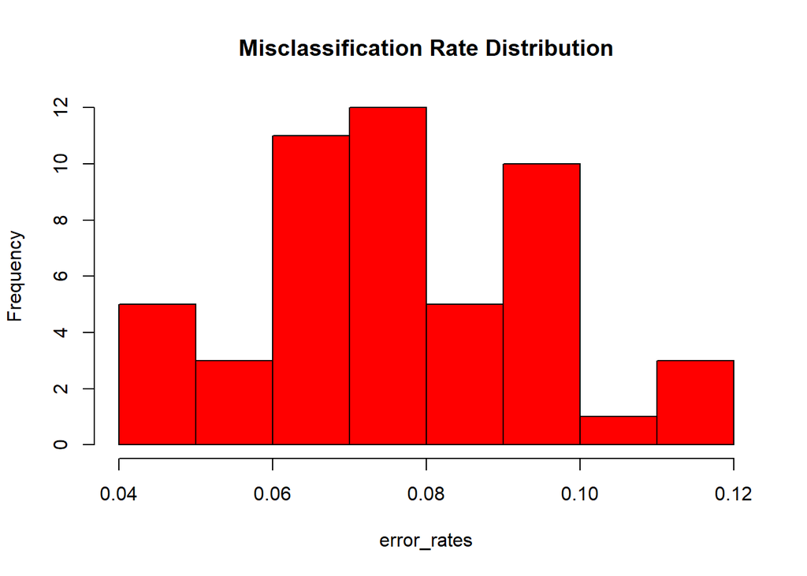

```r
hist(error_rates, main = "Misclassification Rate Distribution", col = "red")
```

# More Feature Engineering

## Previous Application Status as a Predictor

Let’s try to see if we can increase the accuracy of our model by adding another important feature: previous application status. We can join this table on the training data (temp_processed).

The name of this column is NAME_CONTRACT_STATUS.

SK_ID_CURR is the current loan ID (in temp_processed). SK_ID_PREV is the loan ID of the previous application

```r
length(which(temp_processed$SK_ID_CURR %in% previous_app$SK_ID_CURR == FALSE)) / nrow(temp_processed) * 100
```

```
## [1] 5.350703
```

```r
mean(is.na(previous_app$NAME_CONTRACT_STATUS))
```

```
## [1] 0
```

We notice that 5.35% of clients do NOT have a previous application. In other words, it is their first time with Home Credit and we are not able to find their ID in previous_app.

When we do a left join (temp_processed on previous_app) we will get some NA values. There are no NA values in previous_app$NAME_CONTRACT_STATUS, so NA values of NAME_CONTRACT_STATUS after the resulting join will only mean that the client is new to Home Credit so a match could not be found with previous_app.

When we bring this feature in the model, we will impute that 5.35% of rows that have NA for previous status.

In current table, each row is a unique ID. There are no duplicates.

However, there are duplicate SK_ID_CURR in the previous_app table. This means that some clients had multiple previous applications for loans from Home Credit.

For instance, let’s look at one client.

```r
sqldf("SELECT DAYS_DECISION, NAME_CONTRACT_STATUS
       FROM previous_app
       WHERE SK_ID_CURR == 100008
       ORDER BY DAYS_DECISION")
```

```
##   DAYS_DECISION NAME_CONTRACT_STATUS
## 1         -2536             Approved
## 2         -2333             Approved
## 3          -639             Approved
## 4          -370             Approved
## 5           -82             Canceled
```

For predicting default risk using NAME_CONTRACT_STATUS, we have some options.

The first option is that we can only grab information about the LATEST loan application of the client in the previous_app table. We could choose to do this is because I am hypothesizing that the latest previous loan application status would be most indictative of the ability to repay on time or not.

For instance, I believe that just because Home Credit refused to give a loan to a client 7 or 8 years ago does not mean that that client is in the present unable to repay loans on time and will default. People’s financial status change over time, especially after many years.

This is why looking at the most recent previous application status might be a better idea.

Now, we have a possible issue with this option.

What if we have a client in which there is only 1 previous loan application for him or her, and DAYS_DECISION (the time difference in days between current loan application and previous loan application) is very big so therefore the previous loan application was submitted several or many years ago?

What if we have a client in which there are multiple previous loan applications for him or her but DAYS_DECISION are all very big? In other words, those applications were all submitted years before the current application.

In both of these cases, if it is true that the status of applications years ago does not predict default risk well, then this feature might not be useful in predicting default risk.

However, let’s look at how many clients actually have their latest previous loan application decision made a long time ago. If there aren’t that many of these clients, then it might be worth it to make this feature.

I will define “a long time ago” as 5 years. Therefore, I am assuming that previous status of an application made more than 5 years ago from current application would not be indicative of repay ability of current loan.

Since DAYS_DECISION is in days, let’s convert 5 years to days. This is 5 * 365 = 1825.

```r
as.vector(unlist(sqldf("SELECT COUNT(*)

       FROM

       (SELECT SK_ID_CURR, MAX(DAYS_DECISION) AS lastest_application
       FROM previous_app
       GROUP BY SK_ID_CURR
       HAVING MAX(DAYS_DECISION) < -1825)"))) /  length(unique(previous_app$SK_ID_CURR))
```

```
## [1] 0.04631747
```

This is good and probably won’t affect the predictor that much. If my logic and reasoning is correct, the status/decision of the latest previous application could therefore be useful in predicting default disk.

First, let’s check to see what NAME_CONTRACT_STATUS contains.

```r
levels(previous_app$NAME_CONTRACT_STATUS)
```

```
## [1] "Approved"     "Canceled"     "Refused"      "Unused offer"
```

We see that the status of the previous application was either that it was accepted, canceled, refused, or unused.

For the purposes of building this model, I am going to group both “approved” and “unused offer” into just “approved”.

The justification for this is that an unused offer still indicates that the client was accepted for the loan. The only difference is that he or she chose to not go through with taking out the loan in the end.

```r
previous_app$NAME_CONTRACT_STATUS <- combineLevels(previous_app$NAME_CONTRACT_STATUS,

              levs = c("Approved", "Unused offer"),

              newLabel = c("Approved"))
```

```
## The original levels Approved Canceled Refused Unused offer
## have been replaced by Canceled Refused Approved
```

We check to make sure this worked properly, and indeed it did.

```r
levels(previous_app$NAME_CONTRACT_STATUS)
```

```
## [1] "Canceled" "Refused"  "Approved"
```

Now, we will identify the ranks of each previous application, grouped by the client (we will use SK_ID_CURR). This is the first step to retrieve the latest application for each client.

```r
library(data.table)
previous_app$DAYS_DECISION <- -previous_app$DAYS_DECISION
previous_ranked <- setDT(previous_app)[ , rank := rank(DAYS_DECISION), by = SK_ID_CURR]
```

Let’s check to make sure this worked properly. We will use one ID as an example for a quick check.

```r
sqldf("SELECT SK_ID_CURR, DAYS_DECISION, NAME_CONTRACT_STATUS, rank
       FROM previous_ranked
       WHERE SK_ID_CURR == 100009
       ORDER BY rank")
```

```
##   SK_ID_CURR DAYS_DECISION NAME_CONTRACT_STATUS rank
## 1     100009            74             Approved    1
## 2     100009           305             Approved    2
## 3     100009           308             Approved    3
## 4     100009           449             Approved    4
## 5     100009           826             Approved    5
## 6     100009          1511             Approved    6
## 7     100009          1562             Approved    7
```

Now, we will just grab the ID, rank = 1 for each ID, as well as the status associated with rank = 1.

```r
previous_ranked <- sqldf('SELECT SK_ID_CURR, NAME_CONTRACT_STATUS
                          FROM previous_ranked
                          WHERE rank = 1')

head(previous_ranked, 10)
```

```
##    SK_ID_CURR NAME_CONTRACT_STATUS
## 1      271877             Approved
## 2      108129             Approved
## 3      175704             Canceled
## 4      296299             Canceled
## 5      334349             Canceled
## 6      151612             Approved
## 7      315664              Refused
## 8      182450             Approved
## 9      304455             Approved
## 10     118974             Approved
```

Now, we will join our current table (temp_processed) with previous_ranked. This will give us the previous application status for each client along with all the current application information. Then we can proceed to adding it in the model.

```r
temp_processed2 <- sqldf("SELECT current.*, previous.NAME_CONTRACT_STATUS
                          FROM temp_processed AS current
                          LEFT JOIN previous_ranked AS previous
                          ON current.SK_ID_CURR = previous.SK_ID_CURR")
head(temp_processed2,10)
```

```
##    SK_ID_CURR TARGET NAME_CONTRACT_TYPE CODE_GENDER FLAG_OWN_CAR
## 1      100002      1         Cash loans           M            N
## 2      100003      0         Cash loans           F            N
## 3      100004      0    Revolving loans           M            Y
## 4      100006      0         Cash loans           F            N
## 5      100007      0         Cash loans           M            N
## 6      100008      0         Cash loans           M            N
## 7      100009      0         Cash loans           F            Y
## 8      100010      0         Cash loans           M            Y
## 9      100011      0         Cash loans           F            N
## 10     100012      0    Revolving loans           M            N
##    FLAG_OWN_REALTY AMT_INCOME_TOTAL AMT_CREDIT AMT_ANNUITY AMT_GOODS_PRICE
## 1                Y           202500   406597.5     24700.5          351000
## 2                N           270000  1293502.5     35698.5         1129500
## 3                Y            67500   135000.0      6750.0          135000
```

[output cut: 260 more lines]

Before we begin with reconstructing our model based on the new data, let’s examine the default rate for each previous application status.

```r
names(temp_processed2)[names(temp_processed2) == 'NAME_CONTRACT_STATUS'] <- 'PREVIOUS_APP_STATUS'


sqldf("SELECT PREVIOUS_APP_STATUS, AVG(TARGET) AS default_rate
       FROM temp_processed2
       GROUP BY PREVIOUS_APP_STATUS
       ORDER BY AVG(TARGET)")
```

```
##   PREVIOUS_APP_STATUS default_rate
## 1            Approved   0.07365144
## 2            Canceled   0.07726157
## 3                <NA>   0.08432789
## 4             Refused   0.13656208
```

The results are not that surprising. Those who had their latest previous application approved tend to have a lower default rate. This is because there is evidence that the person could be financially capable of paying back their loans on time.

Those who got a rejection from their latest previous loan application are more likely to default (6.29% more).

Now, let’s rebuild our model.

```r
temp_processed2$PREVIOUS_APP_STATUS <- as.factor(temp_processed2$PREVIOUS_APP_STATUS)
```

```r
require(caTools)

temp_processed2$NAME_TYPE_SUITE <- as.factor(temp_processed2$NAME_TYPE_SUITE)
temp_processed2$OCCUPATION_TYPE <- as.factor(temp_processed2$OCCUPATION_TYPE)
temp_processed2$EMERGENCYSTATE_MODE <- as.factor(temp_processed2$EMERGENCYSTATE_MODE)
temp_processed2$AMT_REQ_CREDIT_BUREAU_HOUR <- as.factor(temp_processed2$AMT_REQ_CREDIT_BUREAU_HOUR)
temp_processed2$Number_of_Children <- as.factor(temp_processed2$Number_of_Children)
temp_processed2$Number_of_Family_Members <- as.factor(temp_processed2$Number_of_Family_Members)


set.seed(7720489)

random_rows <- sample(nrow(temp_processed2), 3000)

temp_processed_subset <- temp_processed2[random_rows, ]

temp_processed_subset$SK_ID_CURR <- NULL #this is not a predictor. it is just an ID.

temp_processed_subset$AMT_ANNUITY <- NULL #age of repay includes this predictor already

temp_processed_subset$AMT_CREDIT <- NULL #age of repay includes this predictor already

temp_processed_subset$EXT_SOURCE_2 <- NULL #we don't know how to interpret this column

temp_processed_subset$EXT_SOURCE_3 <- NULL #we don't know how to interpret this column

sample <- sample.split(temp_processed_subset, SplitRatio = 0.8)

temp_processed_subset.train <- subset(temp_processed_subset,sample == TRUE)

temp_processed_subset.test <- subset(temp_processed_subset, sample == FALSE)

set.seed(7720489)

mybag <- randomForest(TARGET ~ ., data = temp_processed_subset.train, na.action = na.roughfix, importance = TRUE)

predicted_stuff <- predict(mybag, newdata = temp_processed_subset.test)

table(predicted = predicted_stuff, actual = temp_processed_subset.test$TARGET)
```

```
##          actual
## predicted   0   1
##         0 124  18
##         1   0   0
```

```r
#Get importance of features with Gini Index
imp <- as.data.frame(importance(mybag))
imp["feature"] <- rownames(imp)
imp <- imp[,c("feature","MeanDecreaseGini")]
sqldf::sqldf("SELECT * FROM imp ORDER BY MeanDecreaseGini DESC")
```

```
##                         feature MeanDecreaseGini
## 1             ORGANIZATION_TYPE     21.055227861
## 2                    DAYS_BIRTH     18.671884528
## 3             DAYS_REGISTRATION     18.598854947
## 4            age_repay_estimate     18.277469345
## 5        DAYS_LAST_PHONE_CHANGE     15.948404522
## 6               DAYS_ID_PUBLISH     15.880067766
## 7                 DAYS_EMPLOYED     15.461142593
## 8               OCCUPATION_TYPE     14.298207544
## 9    WEEKDAY_APPR_PROCESS_START     14.171306187
## 10      HOUR_APPR_PROCESS_START     13.531096248
## 11             AMT_INCOME_TOTAL     13.389371297
## 12              AMT_GOODS_PRICE     13.313759592
## 13   REGION_POPULATION_RELATIVE     13.155565398
## 14               TOTALAREA_MODE      9.450821638
```

[output cut: 63 more lines]

The test error of the random forest model with the extra predictor of latest previous application status actually is larger than the model without it. The test error in this case is 12.676%.

However, it could be that this predictor actually improves our model but by chance the test error for the randomly selected training and test sets is much higher than usual.

Therefore, I have decided to examine the average test error (along with its distribution) of the new model by using 50 different randomly selected seeds to generate different data.

Then, I will use a t-test to see if there is a significant difference in the average test error rates of the 2 models. If the average test error rate of the new model is significantly lower, then I will consider the new predictor as useful.

```r
require(caTools)

set.seed(100)

random_seeds <- sample(seq(1,1000000000), 50)

error_rates2 <- rep(NA, length(random_seeds))


for(i in 1:length(random_seeds)){

set.seed(random_seeds[i])

random_rows <- sample(nrow(temp_processed2), 3000)

temp_processed_subset <- temp_processed2[random_rows, ]

temp_processed_subset$SK_ID_CURR <- NULL #this is not a predictor. it is just an ID.

temp_processed_subset$AMT_ANNUITY <- NULL #age of repay includes this predictor already

temp_processed_subset$AMT_CREDIT <- NULL #age of repay includes this predictor already

temp_processed_subset$EXT_SOURCE_2 <- NULL #we don't know how to interpret this column

temp_processed_subset$EXT_SOURCE_3 <- NULL #we don't know how to interpret this column

set.seed(random_seeds[i])

sample <- sample.split(temp_processed_subset, SplitRatio = 0.8)

temp_processed_subset.train <- subset(temp_processed_subset,sample == TRUE)

temp_processed_subset.test <- subset(temp_processed_subset, sample == FALSE)

set.seed(random_seeds[i])

mybag <- randomForest(TARGET ~ ., data = temp_processed_subset.train, na.action = na.roughfix, importance = TRUE)

predicted_stuff <- predict(mybag, newdata = temp_processed_subset.test)

error_rates2[i] <- (table(predicted = predicted_stuff, actual = temp_processed_subset.test$TARGET)[2] + table(predicted = predicted_stuff, actual = temp_processed_subset.test$TARGET)[3]) / (table(predicted = predicted_stuff, actual = temp_processed_subset.test$TARGET)[1] + table(predicted = predicted_stuff, actual = temp_processed_subset.test$TARGET)[4] + table(predicted = predicted_stuff, actual = temp_processed_subset.test$TARGET)[2] + table(predicted = predicted_stuff, actual = temp_processed_subset.test$TARGET)[3])


}

summary(error_rates2)
```

```
##    Min. 1st Qu.  Median    Mean 3rd Qu.    Max.
## 0.02362 0.04815 0.06202 0.06736 0.07874 0.13669
```

```r
sd(error_rates2)
```

```
## [1] 0.02452187
```

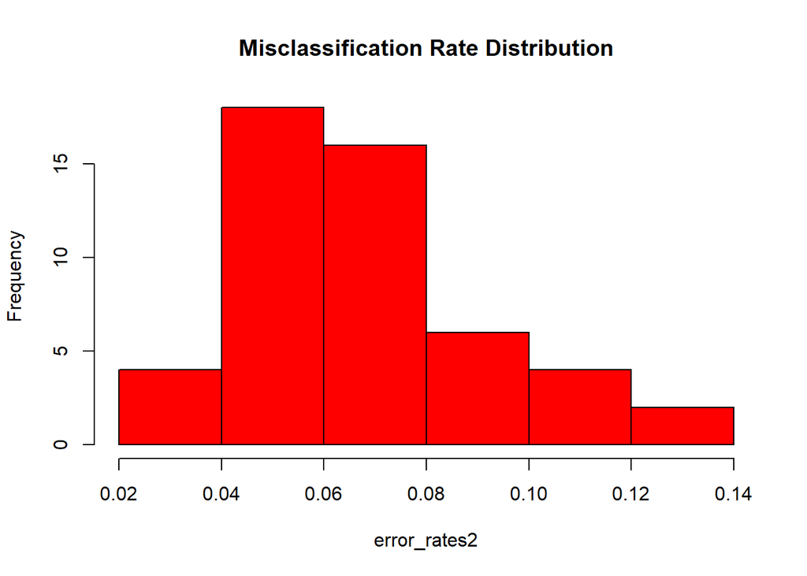

```r
hist(error_rates2, main = "Misclassification Rate Distribution", col = "red")
```

```r
t.test(error_rates2, error_rates, alternative = "less", var.equal = FALSE)
```

```
##
##  Welch Two Sample t-test
##
## data:  error_rates2 and error_rates
## t = -2.183, df = 88.865, p-value = 0.01584
## alternative hypothesis: true difference in means is less than 0
## 95 percent confidence interval:
##          -Inf -0.002222787
## sample estimates:
##  mean of x  mean of y
## 0.06735647 0.07667298
```

Last but not least, we find that the average test error rate of the new model is significantly lower!

# Clustering to Find Different Types of Clients

```r
temp_processed2_x <- temp_processed2[,-2]
head(temp_processed2_x)
```

```
##   SK_ID_CURR NAME_CONTRACT_TYPE CODE_GENDER FLAG_OWN_CAR FLAG_OWN_REALTY
## 1     100002         Cash loans           M            N               Y
## 2     100003         Cash loans           F            N               N
## 3     100004    Revolving loans           M            Y               Y
## 4     100006         Cash loans           F            N               Y
## 5     100007         Cash loans           M            N               Y
## 6     100008         Cash loans           M            N               Y
##   AMT_INCOME_TOTAL AMT_CREDIT AMT_ANNUITY AMT_GOODS_PRICE NAME_TYPE_SUITE
## 1           202500   406597.5     24700.5          351000   Unaccompanied
## 2           270000  1293502.5     35698.5         1129500          Family
## 3            67500   135000.0      6750.0          135000   Unaccompanied
## 4           135000   312682.5     29686.5          297000   Unaccompanied
## 5           121500   513000.0     21865.5          513000   Unaccompanied
## 6            99000   490495.5     27517.5          454500 Spouse, partner
##   NAME_INCOME_TYPE           NAME_EDUCATION_TYPE   NAME_FAMILY_STATUS
```

[output cut: 160 more lines]

K-means clustering will not work when there are NA’s present in the data. We need to start by imputing NA’s using the mice package in R. Unfortunately, the mice package will not run on huge data, so we are forced to take a random sample. I chose 500 random rows which is rather small, but the advanage of this is that I can increase the number of iterations of the mice algorithm to make sure that convergence is present (we check it down below).

I have decided to use the “cart” method in R for the mice algorithm. The reason is that we have some columns that are a linear combination of one or more columns in the data. We know this because for instance, I created the age of repay column which is a combination of some other predictors. By default, the imputation algorithms utilize linear regression so we will have data that cannot be inverted (uninvertible X).

The “cart” method does not try to invert X so we won’t get an error.

```r
library(mice)
set.seed(100)

select_rows <- sample(nrow(temp_processed2_x), 500)

temp_processed2_x_subset <- temp_processed2_x[select_rows, ]

nums <- unlist(lapply(temp_processed2_x_subset, is.numeric))

temp_processed2_x_subset <- temp_processed2_x_subset[ , nums]

tempData <- mice(temp_processed2_x_subset, m = 7,maxit = 30, meth = 'cart', seed = 500)
original <- mice::complete(tempData)

original$YEARS_BEGINEXPLUATATION_MEDI <- NULL

head(original)
```

```
##   SK_ID_CURR AMT_INCOME_TOTAL AMT_CREDIT AMT_ANNUITY AMT_GOODS_PRICE
## 1     209894           148500     900000     26316.0          900000
## 2     191854           135000     377649     18495.0          265500
## 3     296847           157500     942300     30397.5          675000
## 4     120222           270000     810000     40500.0          810000
## 5     267061           247500     675000     33750.0          675000
## 6     272476           202500     886176     29416.5          765000
##   REGION_POPULATION_RELATIVE DAYS_BIRTH DAYS_EMPLOYED DAYS_REGISTRATION
## 1                   0.035792     -19063         -1961             -1788
## 2                   0.005084     -15923         -3605             -7664
## 3                   0.019101     -22486        365243             -5740
## 4                   0.009175     -22154        365243             -5084
## 5                   0.018209     -23171        365243            -10567
## 6                   0.008474     -23843        365243             -3795
##   DAYS_ID_PUBLISH HOUR_APPR_PROCESS_START EXT_SOURCE_2 EXT_SOURCE_3
```

[output cut: 55 more lines]

```r
tempData2 <- complete(tempData)[,-1] #removing ID, useless column

head(tempData2)
```

```
##   AMT_INCOME_TOTAL AMT_CREDIT AMT_ANNUITY AMT_GOODS_PRICE
## 1           148500     900000     26316.0          900000
## 2           135000     377649     18495.0          265500
## 3           157500     942300     30397.5          675000
## 4           270000     810000     40500.0          810000
## 5           247500     675000     33750.0          675000
## 6           202500     886176     29416.5          765000
##   REGION_POPULATION_RELATIVE DAYS_BIRTH DAYS_EMPLOYED DAYS_REGISTRATION
## 1                   0.035792     -19063         -1961             -1788
## 2                   0.005084     -15923         -3605             -7664
## 3                   0.019101     -22486        365243             -5740
## 4                   0.009175     -22154        365243             -5084
## 5                   0.018209     -23171        365243            -10567
## 6                   0.008474     -23843        365243             -3795
##   DAYS_ID_PUBLISH HOUR_APPR_PROCESS_START EXT_SOURCE_2 EXT_SOURCE_3
```

[output cut: 55 more lines]

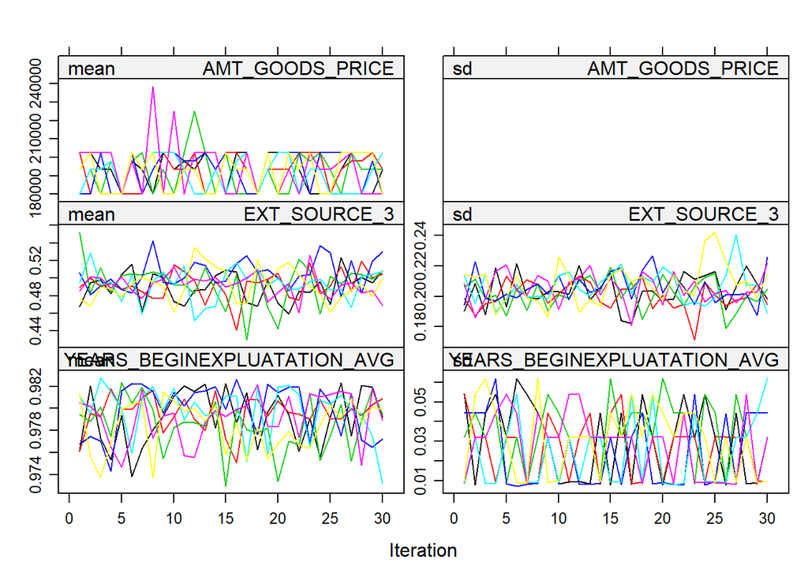

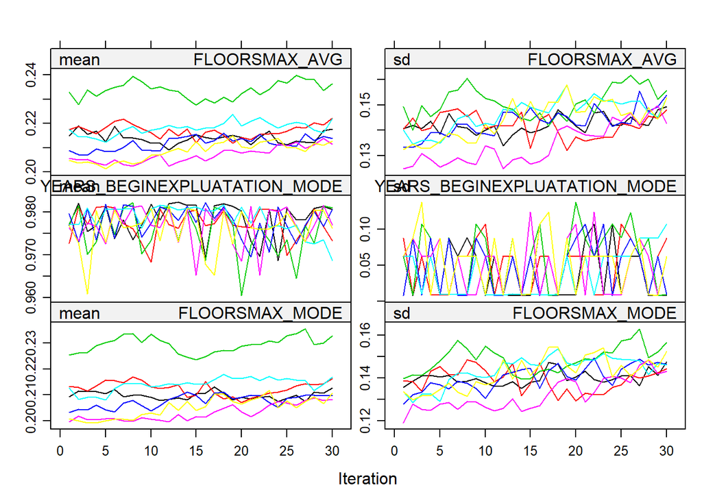

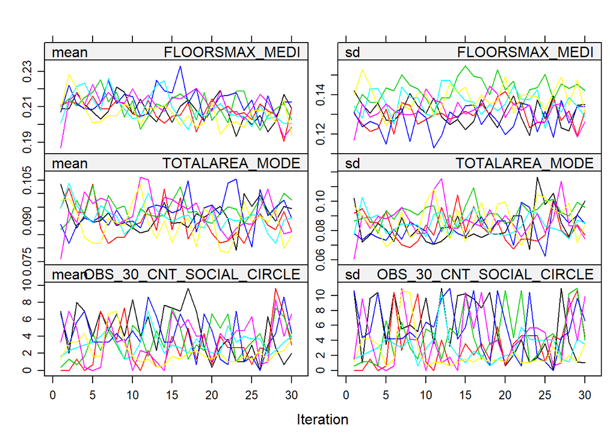

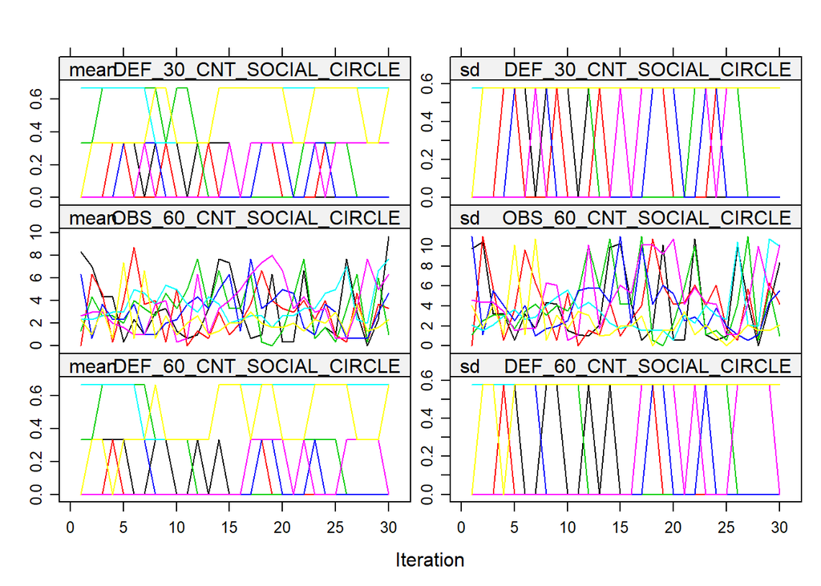

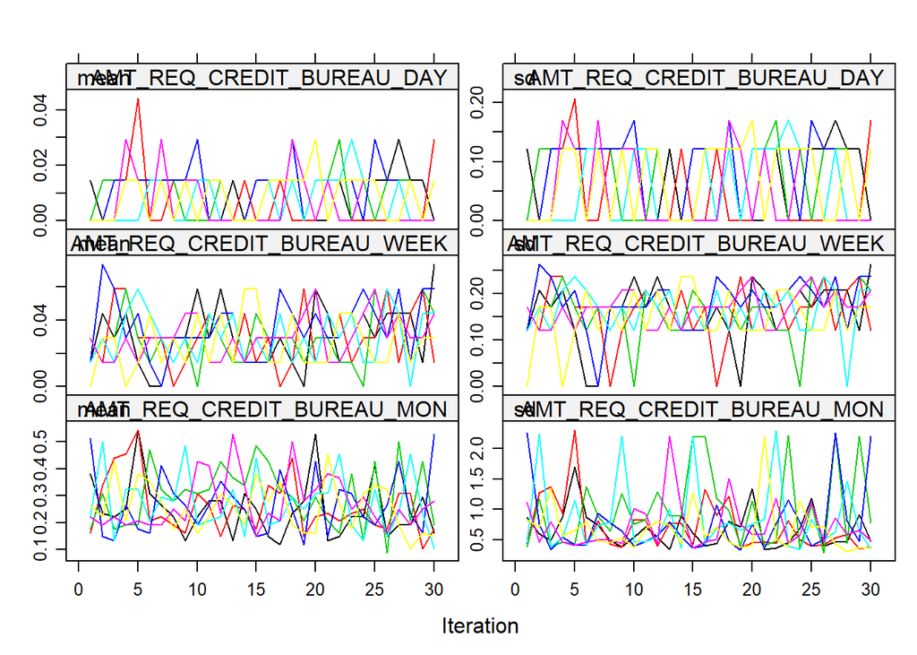

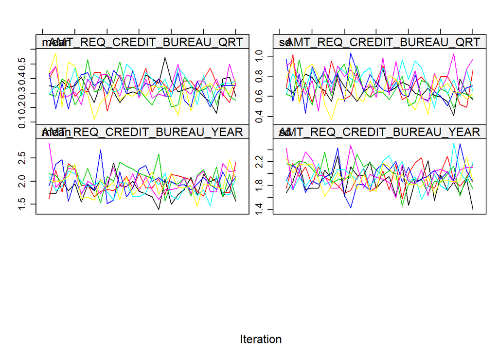

```r
plot(tempData)
```

We generally have convergence for almost all the predictors so I conclude that the mice algorithm did a good job.

```r
tempData2$YEARS_BEGINEXPLUATATION_MEDI <- NULL #this column wasnt able to be imputed
```

We will start by choosing the optimal K value.

```r
library(cluster)
library(factoextra)
```

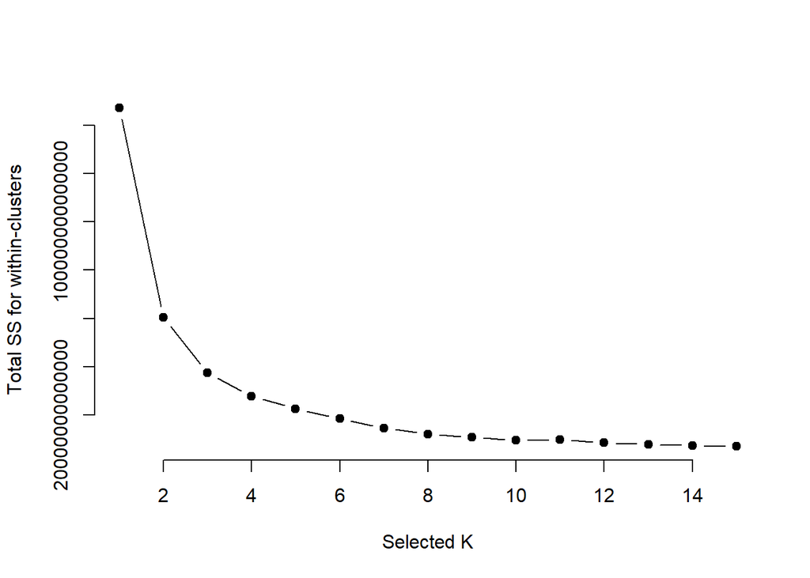

```r
set.seed(123)

our_wss <- function(k) {
  kmeans(tempData2, k, nstart = 10 )$tot.withinss
}


our_kvalues <- 1:15


wss_val <- map_dbl(our_kvalues, our_wss)

plot(our_kvalues, wss_val,
       type="b", pch = 19, frame = FALSE,
       xlab="Selected K",
       ylab="Total SS for within-clusters ")
```

We notice that K = 4 seems to be at the “elbow” of the graph. This means that we have low total SS and also we don’t have a large number of clusters. We could create 10 or 12 clusters but we would lose some interpretibility. It is better to group clients into less clusters such as 4 and then use those 4 to explain default risk.

```r
set.seed(123)

clustering <- kmeans(tempData2, 4 , nstart = 25)
```

```r
final <- as.data.frame(cbind(original, clustering$cluster))

names(final)[names(final) == 'clustering$cluster'] <- 'cluster'

head(final)
```

```
##   SK_ID_CURR AMT_INCOME_TOTAL AMT_CREDIT AMT_ANNUITY AMT_GOODS_PRICE
## 1     209894           148500     900000     26316.0          900000
## 2     191854           135000     377649     18495.0          265500
## 3     296847           157500     942300     30397.5          675000
## 4     120222           270000     810000     40500.0          810000
## 5     267061           247500     675000     33750.0          675000
## 6     272476           202500     886176     29416.5          765000
##   REGION_POPULATION_RELATIVE DAYS_BIRTH DAYS_EMPLOYED DAYS_REGISTRATION
## 1                   0.035792     -19063         -1961             -1788
## 2                   0.005084     -15923         -3605             -7664
## 3                   0.019101     -22486        365243             -5740
## 4                   0.009175     -22154        365243             -5084
## 5                   0.018209     -23171        365243            -10567
## 6                   0.008474     -23843        365243             -3795
##   DAYS_ID_PUBLISH HOUR_APPR_PROCESS_START EXT_SOURCE_2 EXT_SOURCE_3
```

[output cut: 55 more lines]

```r
temp_processed2_with_clusters <- sqldf('SELECT current.*, final.cluster
                                        FROM temp_processed2 AS current
                                        INNER JOIN final
                                        ON current.SK_ID_CURR = final.SK_ID_CURR
                                       ')
```

I will now run random forest on the new data with the extra predictor called ‘cluster’ and I will compute the test error to see if the model performs better. I have also chosen to subset to 51 predictors (the 51 best predictors according to the mean decrease in Gini, which still includes the 2 recent predictors I have added which are previous app status and cluster). I got these 51 predictors by running random forest on all predictors and simply choosing the top 51 (the model with all predictors had a mean test error of 4.9965% but I just haven’t included the code since it wasn’t the best final model).

```r
temp_processed2_with_clusters$NAME_TYPE_SUITE <- as.factor(temp_processed2_with_clusters$NAME_TYPE_SUITE)
temp_processed2_with_clusters$OCCUPATION_TYPE <- as.factor(temp_processed2_with_clusters$OCCUPATION_TYPE)
temp_processed2_with_clusters$EMERGENCYSTATE_MODE <- as.factor(temp_processed2_with_clusters$EMERGENCYSTATE_MODE)
temp_processed2_with_clusters$AMT_REQ_CREDIT_BUREAU_HOUR <- as.factor(temp_processed2_with_clusters$AMT_REQ_CREDIT_BUREAU_HOUR)
temp_processed2_with_clusters$Number_of_Children <- as.factor(temp_processed2_with_clusters$Number_of_Children)
temp_processed2_with_clusters$Number_of_Family_Members <- as.factor(temp_processed2_with_clusters$Number_of_Family_Members)

temp_processed2_with_clusters$PREVIOUS_APP_STATUS <- as.factor(temp_processed2_with_clusters$PREVIOUS_APP_STATUS)
temp_processed2_with_clusters$cluster <- as.factor(temp_processed2_with_clusters$cluster)


set.seed(100)

random_seeds <- sample(seq(1,1000000000), 50)

error_rates4 <- rep(NA, length(random_seeds))


for(i in 1:length(random_seeds)){

set.seed(random_seeds[i])


temp_processed2_with_clusters$SK_ID_CURR <- NULL #this is not a predictor. it is just an ID.

temp_processed2_with_clusters$AMT_ANNUITY <- NULL #age of repay includes this predictor already

temp_processed2_with_clusters$AMT_CREDIT <- NULL #age of repay includes this predictor already

temp_processed2_with_clusters$EXT_SOURCE_2 <- NULL #we don't know how to interpret this column

temp_processed2_with_clusters$EXT_SOURCE_3 <- NULL #we don't know how to interpret this column

set.seed(random_seeds[i])

sample <- sample.split(temp_processed2_with_clusters, SplitRatio = 0.8)

temp_processed_subset.train <- subset(temp_processed2_with_clusters,sample == TRUE)

temp_processed_subset.test <- subset(temp_processed2_with_clusters, sample == FALSE)

set.seed(random_seeds[i])

mybag <- randomForest(TARGET ~ ORGANIZATION_TYPE + OCCUPATION_TYPE + DAYS_ID_PUBLISH + age_repay_estimate + DAYS_REGISTRATION + WEEKDAY_APPR_PROCESS_START + DAYS_BIRTH + HOUR_APPR_PROCESS_START + DAYS_LAST_PHONE_CHANGE + AMT_GOODS_PRICE + DAYS_EMPLOYED + REGION_POPULATION_RELATIVE + AMT_REQ_CREDIT_BUREAU_YEAR + YEARS_BEGINEXPLUATATION_MODE + YEARS_BEGINEXPLUATATION_MEDI + AMT_INCOME_TOTAL + TOTALAREA_MODE + YEARS_BEGINEXPLUATATION_AVG + AMT_REQ_CREDIT_BUREAU_QRT + cluster + DEF_60_CNT_SOCIAL_CIRCLE + OBS_60_CNT_SOCIAL_CIRCLE + Number_of_Children + OBS_30_CNT_SOCIAL_CIRCLE + DEF_30_CNT_SOCIAL_CIRCLE + NAME_FAMILY_STATUS + NAME_INCOME_TYPE + REGION_RATING_CLIENT_W_CITY + REGION_RATING_CLIENT + FLOORSMAX_AVG  +  AMT_REQ_CREDIT_BUREAU_HOUR + FLOORSMAX_MODE + REG_CITY_NOT_LIVE_CITY + FLOORSMAX_MEDI + NAME_TYPE_SUITE + CODE_GENDER + FLAG_DOCUMENT_8 + FLAG_PHONE + REG_CITY_NOT_WORK_CITY + FLAG_WORK_PHONE + FLAG_OWN_CAR + LIVE_CITY_NOT_WORK_CITY + FLAG_OWN_REALTY + Number_of_Family_Members  + FLAG_DOCUMENT_3 + AMT_REQ_CREDIT_BUREAU_MON + FLAG_EMP_PHONE + NAME_EDUCATION_TYPE + AMT_REQ_CREDIT_BUREAU_WEEK + FLAG_EMAIL + PREVIOUS_APP_STATUS, data = temp_processed_subset.train, na.action = na.roughfix, importance = TRUE)

predicted_stuff <- predict(mybag, newdata = temp_processed_subset.test)

error_rates4[i] <- (table(predicted = predicted_stuff, actual = temp_processed_subset.test$TARGET)[2] + table(predicted = predicted_stuff, actual = temp_processed_subset.test$TARGET)[3]) / (table(predicted = predicted_stuff, actual = temp_processed_subset.test$TARGET)[1] + table(predicted = predicted_stuff, actual = temp_processed_subset.test$TARGET)[4] + table(predicted = predicted_stuff, actual = temp_processed_subset.test$TARGET)[2] + table(predicted = predicted_stuff, actual = temp_processed_subset.test$TARGET)[3])



}

summary(error_rates4)
```

```
##     Min.  1st Qu.   Median     Mean  3rd Qu.     Max.
## 0.000000 0.008333 0.050125 0.049965 0.071429 0.153846
```

```r
sd(error_rates4)
```

```
## [1] 0.03842514
```

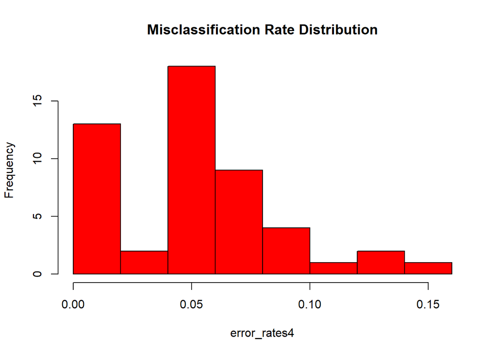

```r
hist(error_rates4, main = "Misclassification Rate Distribution", col = "red")
```

```r
#Get importance of features with Gini Index
imp <- as.data.frame(importance(mybag))
imp["feature"] <- rownames(imp)
imp <- imp[,c("feature","MeanDecreaseGini")]
sqldf::sqldf("SELECT * FROM imp ORDER BY MeanDecreaseGini DESC")
```

```
##                         feature MeanDecreaseGini
## 1             ORGANIZATION_TYPE       3.22267137
## 2               OCCUPATION_TYPE       3.18061089
## 3               DAYS_ID_PUBLISH       3.11339183
## 4            age_repay_estimate       2.69697187
## 5                    DAYS_BIRTH       2.42052861
## 6             DAYS_REGISTRATION       2.32697065
## 7    WEEKDAY_APPR_PROCESS_START       2.25783098
## 8        DAYS_LAST_PHONE_CHANGE       2.22192713
## 9       HOUR_APPR_PROCESS_START       2.00971525
## 10                DAYS_EMPLOYED       1.99709461
## 11              AMT_GOODS_PRICE       1.95191194
## 12   REGION_POPULATION_RELATIVE       1.85560618
## 13   AMT_REQ_CREDIT_BUREAU_YEAR       1.73541690
## 14             AMT_INCOME_TOTAL       1.69854357
```

[output cut: 37 more lines]

# Limitations

Some of the limitations are that we have decided to impute missing values (both categorical and numeric). The issue with doing this is that we are, whether we like it or not, introducing bias by assuming that the missign data will be the mean or mode, depending on the data type. Even though it seemed like the mice algorithm converged, there is probably still some bias introduced.

In addition, in the interest of time, I had decided to only select 500 rows randomly from the data. The final model was only run on 500 rows since we had to create the cluster predictor from only 500 rows (and then inner joined back with bigger data to get all predictors for those 500).

There is a chance the model performance might differ if I selected maybe 1000, 5000, or 10000 rows.

Another limitation is that I assumed that the latest previous application status is indicative of the client’s ability to repay. Perhaps creating the latest previous application status predictor a bit differently (like for instance, taking the mode of all their previous application statuses) would have resulted in less test error.

Some data is unbalanced. For instance, within certain categorical predictors, the number of clients in certain levels is very low and so methods to explore unbalanced data could have been used to improve the model.

# Conclusions

So, our final model is a random forest model with 51 predictors. We managed to reduce the number of predictors by quite a bit, and mean test error actually remained the same (being 4.9965%). This means we can explain default risk but with much less predictors which is definately better.

A highlight of some of the 51 predictors is:

occupation type of the client organization that the client works for age that the person is expected to completely repay the loan (I created this earlier) how old the person is (DAYS_BIRTH) how many days before the application the client changed his or her phone number how densely populated the city in which the client lives in is (REGION_POPULATION_RELATIVE) how many days before the application the person started current employment income of the client cluster that we created number of children the client has gender of the client whether the client owns a flat or house whether client provided a home phone number number of family members the client has previous app status

Of course, there are many more, but I have chosen just to describe some of the columns which are bit more easily interpretable and interesting. If you are curious about looking at the description of all the columns, you can refer to the columns_description dataset.

# Literature Review

Another person found balance to be a useful predictor as well.

You can view it here: https://medium.com/henry-jia/bank-loan-default-prediction-with-machine-learning-e9336d19dffa

Also here: https://towardsdatascience.com/predicting-loan-repayment-5df4e0023e92